# Exploratory Analysis

Parsa Khazaeepoul, Yuna, Grace, Jinwoo

11/19/2021

### Introduction

We chose for our domain to be unemployment rates in the U.S. on a national level. We chose unemployment rates as we hope to uncover trends and analyze the data to understand it better. Our data set includes various metrics that allow us to track education levels and races unemployment rates through time to help us better represent how rates have changed through the years.

### Summary

We were able to gather a variety of information from the analysis of our data, and it can be best summarized as follows. In the year 2020, the average rate of employment for White people was 3.4%. For Black people in the same year, it was 6.2%. For Asian people, it was 3.2%. For Hispanic people, it was 4.9%. The Year and Associated month with the highest unemployment rate for White people was April 2010.

### Table of Aggregated Data (Grouped by Race)

Unemployment rates grouped by race:

| Date | White | Black | Asian | Hispanic |
| --- | --- | --- | --- | --- |
| Jan-2010 | 8.8 | 16.5 | 8.3 | 12.9 |
| Jan-2011 | 8.1 | 15.8 | 6.8 | 12.3 |
| Jan-2012 | 7.4 | 13.6 | 6.7 | 10.7 |
| Jan-2013 | 7.1 | 13.7 | 6.4 | 9.7 |
| Jan-2014 | 5.7 | 12.1 | 4.7 | 8.3 |
| Jan-2015 | 4.9 | 10.3 | 4.0 | 6.7 |
| Jan-2016 | 4.2 | 8.7 | 3.6 | 5.8 |
| Jan-2017 | 4.2 | 7.5 | 3.7 | 5.8 |
| Jan-2018 | 3.5 | 7.5 | 3.0 | 5.0 |
| Jan-2019 | 3.5 | 6.8 | 3.1 | 4.8 |
| Jan-2020 | 3.1 | 6.0 | 3.0 | 4.3 |
| Feb-2010 | 8.9 | 16.1 | 8.2 | 12.7 |
| Feb-2011 | 8.1 | 15.5 | 6.7 | 11.8 |
| Feb-2012 | 7.4 | 14.0 | 6.2 | 10.9 |
| Feb-2013 | 6.8 | 13.8 | 6.0 | 9.7 |
| Feb-2014 | 5.8 | 11.8 | 5.9 | 8.2 |
| Feb-2015 | 4.7 | 10.1 | 4.0 | 6.8 |
| Feb-2016 | 4.3 | 8.5 | 3.8 | 5.4 |
| Feb-2017 | 4.0 | 7.9 | 3.4 | 5.5 |
| Feb-2018 | 3.7 | 6.7 | 2.9 | 4.9 |
| Feb-2019 | 3.3 | 6.9 | 3.1 | 4.3 |
| Feb-2020 | 3.1 | 5.8 | 2.5 | 4.4 |
| Mar-2010 | 8.9 | 16.8 | 7.6 | 12.9 |
| Mar-2011 | 8.0 | 15.8 | 7.3 | 11.6 |
| Mar-2012 | 7.3 | 14.0 | 6.4 | 10.6 |
| Mar-2013 | 6.7 | 13.0 | 5.1 | 9.3 |
| Mar-2014 | 5.8 | 12.1 | 5.5 | 7.9 |
| Mar-2015 | 4.8 | 9.9 | 3.2 | 6.8 |
| Mar-2016 | 4.3 | 8.9 | 3.9 | 5.5 |
| Mar-2017 | 3.9 | 7.9 | 3.3 | 5.0 |

[output cut: 102 more lines]

### Charts displaying information from data (Visualizations)

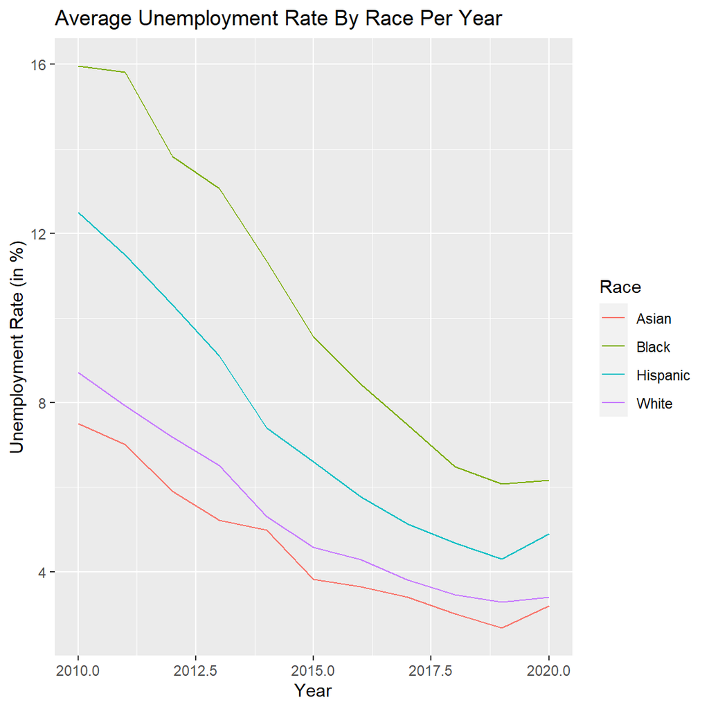

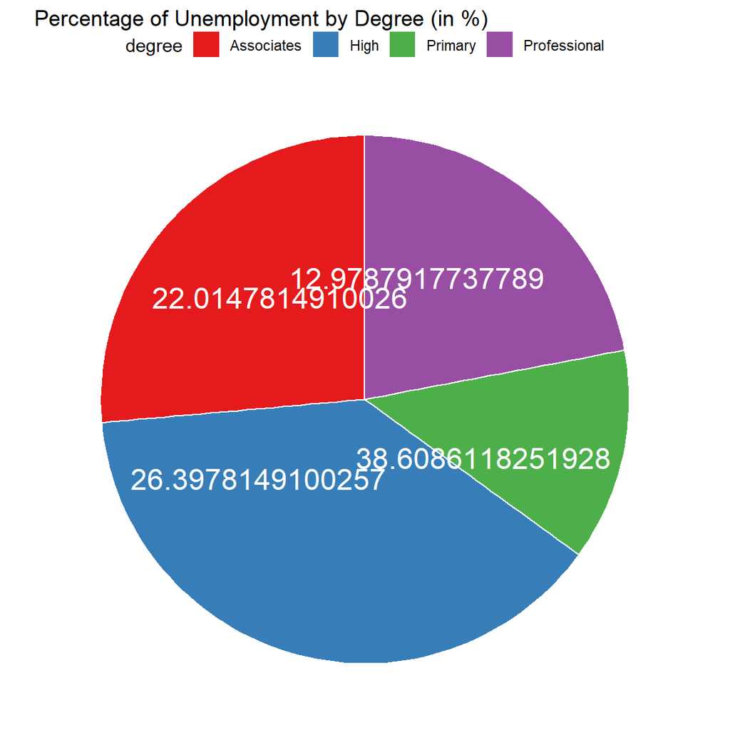

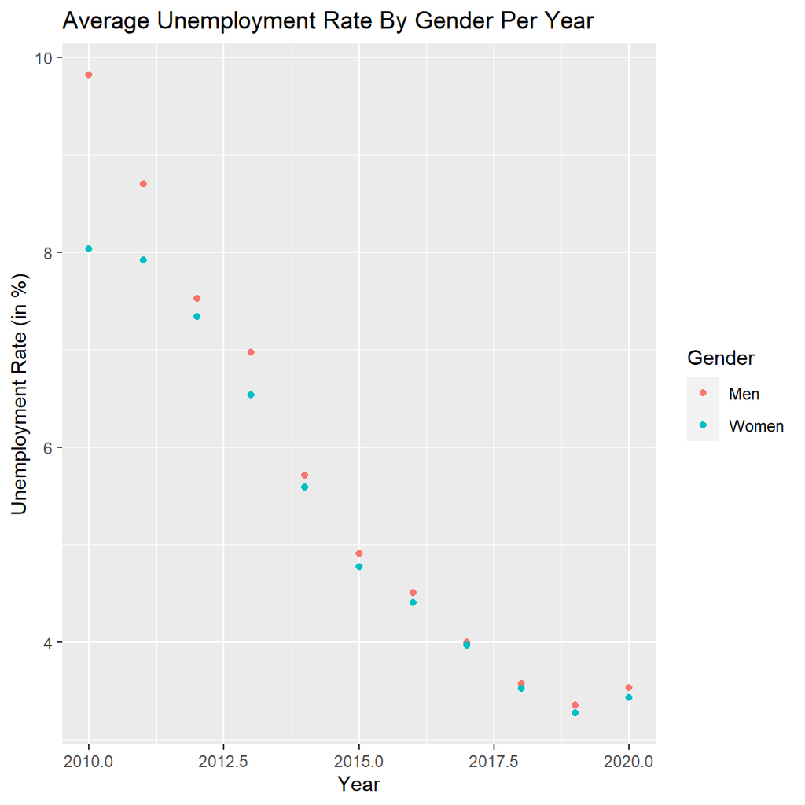

The purpose for including chart one was to visually depict the relations between race and unemployment rate. The insight gained from this was that certain races had higher rates of unemployment then other races (Notably, Black and Hispanic’s had the highest unemployment rates).

The purpose for including chart th ree was to visually depict the relations between gender and unemployment rate. The insight gained from this was that certain genders had lower rates of unemployment then other genders (Notably, Men had a higher unemployment rate than women).